## Minería Estadística de Datos

# Laboratorio I: Análisis de Conglomerados

# Ejemplo 1: Fichero “agriculture”

Producto Nacional Bruto (GNP) per capita y porcentaje de la población que trabaja en la agricultura para cada pais de la Unión Europea en 1993

```r
library(cluster)
data(agriculture)
names(agriculture)
```

```
## [1] "x" "y"
```

```r
agriculture
```

```
##        x    y
## B   16.8  2.7
## DK  21.3  5.7
## D   18.7  3.5
## GR   5.9 22.2
## E   11.4 10.9
## F   17.8  6.0
## IRL 10.9 14.0
## I   16.6  8.5
## L   21.0  3.5
## NL  16.4  4.3
## P    7.8 17.4
## UK  14.0  2.3
```

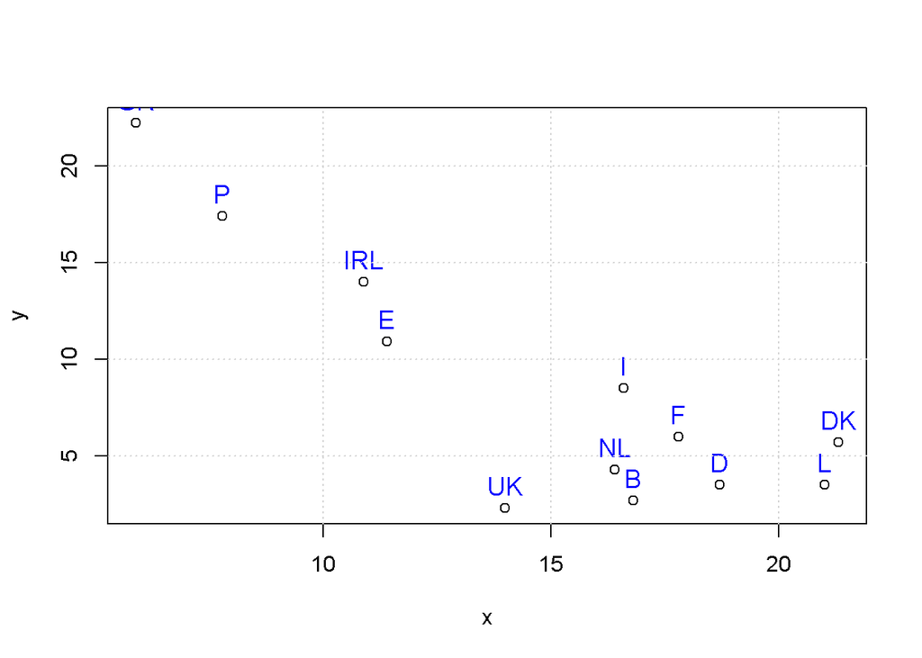

```r
plot(agriculture)
text( agriculture, row.names(agriculture), cex=1.2, pos=3, col="blue")
grid()
```

Cálculo de la matriz de distancias o disimilaridades

dist(datos, method = “euclidean”, p = 2, diag = FALSE, upper = FALSE)

datos : matriz de datos

method : distancia que se va a usar. Puede ser: “euclidean”, “maximum”, “manhattan”, “canberra”, “binary” or “minkowski”.

p : Exponente de la distancia de Minkowski

diag : Lógico. Indica si proporciona la diagonal de la matriz de distancias a través de la orden “print.dist”

upper : Lógico. Indica si proporciona la diagonal de la matriz de distancias a través de la orden “print.dist”

```r
D <- dist(agriculture)
print(round(D,2))
```

```
##         B    DK     D    GR     E     F   IRL     I     L    NL     P
## DK   5.41
## D    2.06  3.41
## GR  22.34 22.57 22.66
## E    9.82 11.18 10.39 12.57
## F    3.45  3.51  2.66 20.10  8.06
## IRL 12.75 13.31 13.08  9.60  3.14 10.56
## I    5.80  5.47  5.42 17.38  5.73  2.77  7.92
## L    4.28  2.22  2.30 24.04 12.12  4.06 14.57  6.66
## NL   1.65  5.10  2.44 20.75  8.28  2.20 11.15  4.20  4.67
## P   17.24 17.86 17.66  5.16  7.43 15.16  4.60 12.52 19.17 15.67
## UK   2.83  8.05  4.85 21.49  8.98  5.30 12.10  6.72  7.10  3.12 16.32
```

# Agrupamiento jerárquico “hclust”

hclust(d, method = “complete”)

d : matriz de disimilaridad creada por “dist”

method : método de agrupación. Debe ser uno de los siguientes: “ward” - Método de Ward, “single” - Unión simple o vecino más cercano “complete” - Unión completa o vecino más lejano, “average” - Unión media de grupo no ponderada (UPGMA), (media de distancias entre casos de un grupo y otro) “median” - Método de la mediana “centroid” - Método del centroide “mcquitty” - Método de McQuitty correspondiente a unión media ponderada como semi-suma de las distancias entre clusters en la etapa anterior.

```r
agr1 <-  hclust(D, method = "ward.D")
agr1
```

```
##
## Call:
## hclust(d = D, method = "ward.D")
##
## Cluster method   : ward.D
## Distance         : euclidean
## Number of objects: 12
```

```r
str(agr1)
```

```
## List of 7
##  $ merge      : int [1:11, 1:2] -1 -2 -3 -6 -5 -12 -4 4 2 5 ...
##  $ height     : num [1:11] 1.65 2.22 2.45 2.77 3.14 ...
##  $ order      : int [1:12] 2 9 6 8 12 3 1 10 5 7 ...
##  $ labels     : chr [1:12] "B" "DK" "D" "GR" ...
##  $ method     : chr "ward.D"
##  $ call       : language hclust(d = D, method = "ward.D")
##  $ dist.method: chr "euclidean"
##  - attr(*, "class")= chr "hclust"
```

```r
agr1$labels
```

```
##  [1] "B"   "DK"  "D"   "GR"  "E"   "F"   "IRL" "I"   "L"   "NL"  "P"
## [12] "UK"
```

```r
agr1$height
```

```
##  [1]  1.649242  2.220360  2.448061  2.773085  3.140064  4.377324  5.162364
##  [8]  7.248300  8.714398 12.950293 54.845952
```

```r
agr1$merge
```

```
##       [,1] [,2]
##  [1,]   -1  -10
##  [2,]   -2   -9
##  [3,]   -3    1
##  [4,]   -6   -8
##  [5,]   -5   -7
##  [6,]  -12    3
##  [7,]   -4  -11
##  [8,]    4    6
##  [9,]    2    8
## [10,]    5    7
## [11,]    9   10
```

```r
agr1$dist.method
```

```
## [1] "euclidean"
```

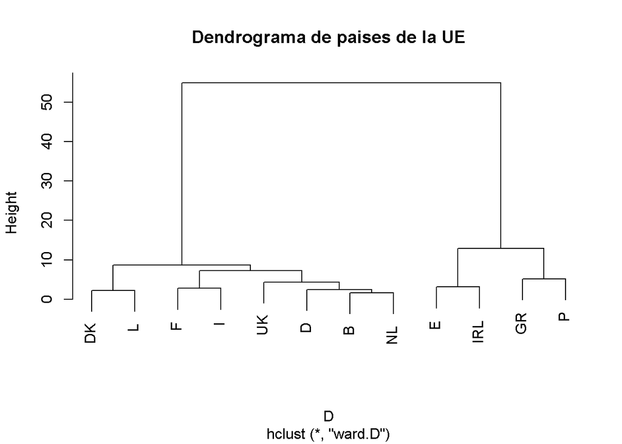

```r
plot(agr1,main="Dendrograma de paises de la UE")
```

```r
agr2 <-  hclust(D, method = "complete")
agr2
```

```
##
## Call:
## hclust(d = D, method = "complete")
##
## Cluster method   : complete
## Distance         : euclidean
## Number of objects: 12
```

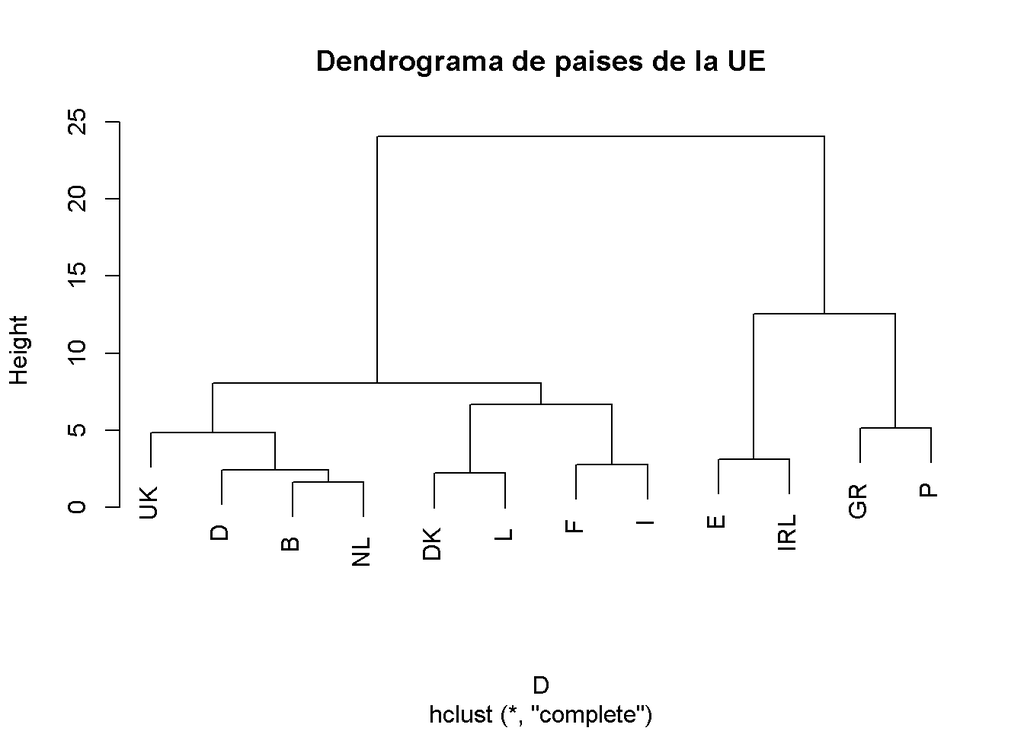

```r
plot(agr2,main = "Dendrograma de paises de la UE")
```

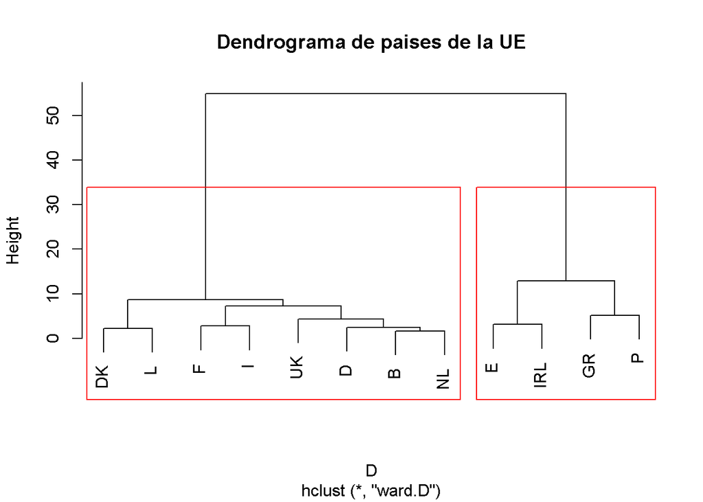

```r
plot(agr1,main="Dendrograma de paises de la UE")
rect.hclust(agr1, k=2,border="red")
```

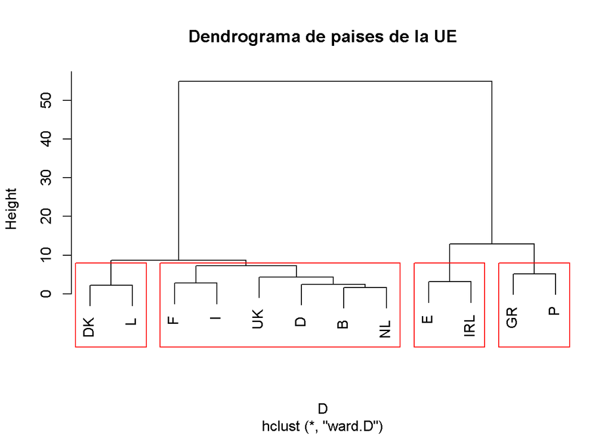

```r
plot(agr1,main="Dendrograma de paises de la UE")
rect.hclust(agr1, k=4,border="red")
```

```r
cong.pertenencia <- cutree(agr1, k = 4) # cluster de cada caso para k clusters
cong.pertenencia
```

```
##   B  DK   D  GR   E   F IRL   I   L  NL   P  UK
##   1   2   1   3   4   1   4   1   2   1   3   1
```

Cálculo de los centros de cada uno de los clusters

```r
nc <- 4
cbind(rownames(agriculture),cong.pertenencia)
```

```
##           cong.pertenencia
## B   "B"   "1"
## DK  "DK"  "2"
## D   "D"   "1"
## GR  "GR"  "3"
## E   "E"   "4"
## F   "F"   "1"
## IRL "IRL" "4"
## I   "I"   "1"
## L   "L"   "2"
## NL  "NL"  "1"
## P   "P"   "3"
## UK  "UK"  "1"
```

```r
centros <- NULL
for(k in 1:nc){
  centros <- rbind(centros, colMeans(agriculture[cong.pertenencia == k,]))
}
row.names(centros) <- 1:nc
round(centros,2)
```

```
##       x     y
## 1 16.72  4.55
## 2 21.15  4.60
## 3  6.85 19.80
## 4 11.15 12.45
```

# Agrupamiento jerárquico aglomerativo “agnes”

agnes(datos, diss = inherits(x, “dist”), metric = “euclidean”,stand = FALSE, method = “average”, par.method, keep.diss = n < 100, keep.data = !diss)

datos : matriz de datos o data frame, aunque también puede ser una matriz de distancias o disimilaridades (debe indicarse en “diss”)

diss : lógica. Si TRUE (default for dist or dissimilarity objects), entonces “datos” se asume como una matriz de disimiliaridad. Si FALSE, entonces “datos” es una matriz de datos (casos en filas, variables en columnas)

metric : métrica o distancia utilizada para el cálculo de disimilaridades entre observaciones o casos. Las opciones son: “euclidean” y “manhattan”. Si “datos” es una matriz de disimilaridades este argumento se ignora.

stand : lógica. Si TRUE, las medidas de “datos” se estandarizan antes de calcular las disimilaridades. Se estandariza cada variable, restando la media y dividiendo por la desviación media absoluta.

```
      Si "datos" es una matriz de disimilaridades este argumento se ignora.
```

method : Metodo de agrupación:

```
      "average" - Unión media de grupo no ponderada (UPGMA), (media de distancias   entre casos de un grupo y otro). También conocida como método de inter-grupos

     "single" - Unión simple o vecino más cercano

      "complete" - Unión completa o vecino más lejano,

      "ward" - Método de Ward,

      "weighted" - Unión media ponderada (método de Mc Quitty) y
      su generalización "flexible" que utiliza la fórmula de Lance-Williams

      Por defecto, "average".
```

keep.diss, keep.data : lógicas, indicando si la matriz de disimilaridades o de datos deben ser incluidos en el objeto resultante.

par.method : vector para el cálculo de la fórmula de Lance-Willians

```r
agnclus <- agnes(agriculture, metric = "manhattan", stand = TRUE)
str(agnclus)
```

```
## List of 9
##  $ order    : int [1:12] 1 10 3 6 8 2 9 12 4 11 ...
##  $ height   : num [1:11] 0.409 0.671 0.755 1.076 1.321 ...
##  $ ac       : num 0.808
##  $ merge    : int [1:11, 1:2] -1 -2 1 -5 3 5 6 -4 7 8 ...
##  $ diss     :Classes 'dissimilarity', 'dist'  atomic [1:66] 1.688 0.622 6.463 2.918 0.886 ...
##   .. ..- attr(*, "Size")= int 12
##   .. ..- attr(*, "Metric")= chr "manhattan"
##   .. ..- attr(*, "Labels")= chr [1:12] "B" "DK" "D" "GR" ...
##  $ call     : language agnes(x = agriculture, metric = "manhattan", stand = TRUE)
##  $ method   : chr "average"
##  $ order.lab: chr [1:12] "B" "NL" "D" "F" ...
##  $ data     : num [1:12, 1:2] 0.471 1.577 0.938 -2.208 -0.856 ...
##   ..- attr(*, "dimnames")=List of 2
##   .. ..$ : chr [1:12] "B" "DK" "D" "GR" ...
##   .. ..$ : chr [1:2] "x" "y"
##   ..- attr(*, "scaled:center")= Named num [1:2] 14.88 8.42
##   .. ..- attr(*, "names")= chr [1:2] "x" "y"
##   ..- attr(*, "scaled:scale")= Named num [1:2] 4.07 5.15
##   .. ..- attr(*, "names")= chr [1:2] "x" "y"
##  - attr(*, "class")= chr [1:2] "agnes" "twins"
```

```r
summary(agnclus)
```

```
## Object of class 'agnes' from call:
##  agnes(x = agriculture, metric = "manhattan", stand = TRUE)
## Agglomerative coefficient:  0.8084256
## Order of objects:
##  [1] B   NL  D   F   I   DK  L   UK  GR  P   E   IRL
## Merge:
##       [,1] [,2]
##  [1,]   -1  -10
##  [2,]   -2   -9
##  [3,]    1   -3
##  [4,]   -5   -7
##  [5,]    3   -6
##  [6,]    5   -8
##  [7,]    6    2
##  [8,]   -4  -11
##  [9,]    7  -12
## [10,]    8    4
## [11,]    9   10
## Height:
##  [1] 0.4088056 0.6712970 0.7554824 1.0763604 1.3207562 0.5006743 1.5760175
##  [8] 4.4125360 1.3984306 2.4830704 0.7244841
##
## 66 dissimilarities, summarized :
##    Min. 1st Qu.  Median    Mean 3rd Qu.    Max.
##  0.4088  1.2084  2.3808  2.8230  4.1134  7.3397
## Metric :  manhattan
## Number of objects : 12
##
## Available components:
## [1] "order"     "height"    "ac"        "merge"     "diss"      "call"
## [7] "method"    "order.lab" "data"
```

```r
agnclus$method
```

```
## [1] "average"
```

```r
agnclus$ac
```

```
## [1] 0.8084256
```

# Representación gráfica del objeto creado

plot(x, ask = FALSE, which.plots = NULL, main = NULL, sub = paste(“Agglomerative Coefficient =”,round(x$ac, digits = 2)), , …)

x : objeto creado por “agnes”

ask : lógica. Si TRUE y which.plots=NULL, se puede trabajar de forma interactiva which.plots : Vector entero o NULL(por defecto). Si contiene al 1 se representa un gráfico “banner”, si contiene al 2 representa un dendrograma.

main : título principal

sub : subtítulo

```r
#plot(agnclus,which.plots=c(2),main="Dendrograma de paises de la UE")

#par(mfrow=c(1,2))
#plot(agnclus,which.plots=c(2),main="Dendrograma de paises de la UE")
#plot(agnclus,which.plots=c(1),main="Banner de paises de la UE")
#par(mfrow=c(1,1))
```

# Agrupamiento jerárquico divisivo “diana”

diana(dd, diss = inherits(dd, “dist”), metric = “euclidean”, stand = FALSE)

dd : matriz de datos o matriz de disimilaridades creada por “dist” o “daisy”

diss : logica. Si dd es una matriz de distancias o de disimilaridades, entonces TRUE. Si dd es una matriz de datos, entonces FALSE.

metric : especificación de la m?trica que se debe usar. Opciones: “euclidean” (por defecto), “manhattan”. Si dd es una matriz de disimilaridades o distancias, este argumento no es necesario

stand : lógica. Si TRUE, las medidas de “datos” se estandarizan antes de calcular las disimilaridades.

```r
agd <-  diana(agriculture, metric = "manhattan", stand = TRUE )
agd
```

```
## Merge:
##       [,1] [,2]
##  [1,]   -1  -10
##  [2,]   -2   -9
##  [3,]   -3   -6
##  [4,]   -5   -7
##  [5,]    1  -12
##  [6,]    2    3
##  [7,]   -4  -11
##  [8,]    5   -8
##  [9,]    8    6
## [10,]    7    4
## [11,]    9   10
## Order of objects:
##  [1] B   NL  UK  I   DK  L   D   F   GR  P   E   IRL
## Height:
##  [1] 0.4088056 0.9779013 1.8421424 2.4536949 0.5006743 1.2715233 0.7063356
##  [8] 7.3396907 1.3984306 3.5445277 0.7244841
## Divisive coefficient:
## [1] 0.8830843
##
## Available components:
## [1] "order"     "height"    "dc"        "merge"     "diss"      "call"
## [7] "order.lab" "data"
```

```r
agd$dc
```

```
## [1] 0.8830843
```

```r
agd$height
```

```
##  [1] 0.4088056 0.9779013 1.8421424 2.4536949 0.5006743 1.2715233 0.7063356
##  [8] 7.3396907 1.3984306 3.5445277 0.7244841
```

```r
cbind(agd$merge,agd$height)
```

```
##       [,1] [,2]      [,3]
##  [1,]   -1  -10 0.4088056
##  [2,]   -2   -9 0.9779013
##  [3,]   -3   -6 1.8421424
##  [4,]   -5   -7 2.4536949
##  [5,]    1  -12 0.5006743
##  [6,]    2    3 1.2715233
##  [7,]   -4  -11 0.7063356
##  [8,]    5   -8 7.3396907
##  [9,]    8    6 1.3984306
## [10,]    7    4 3.5445277
## [11,]    9   10 0.7244841
```

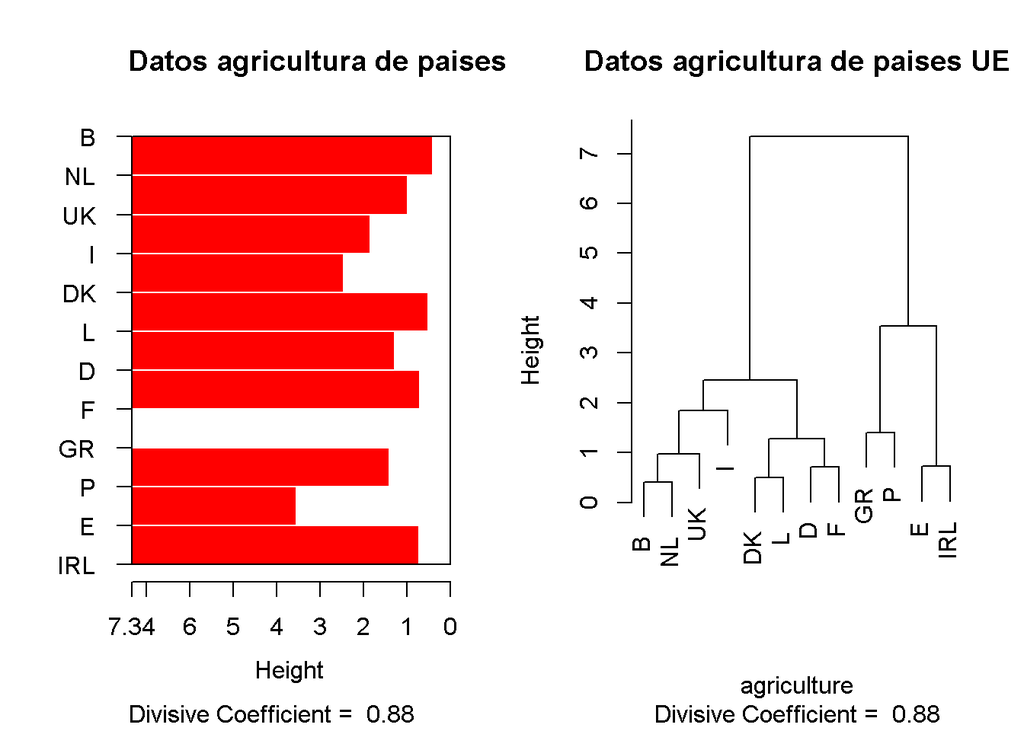

```r
par(mfrow=c(1,2))
plot(agd,main="Datos agricultura de paises UE")
```

```r
par(mfrow=c(1,1))


agd <-  diana(agriculture, metric = "euclidean", stand = TRUE )
agd
```

```
## Merge:
##       [,1] [,2]
##  [1,]   -1  -10
##  [2,]   -2   -9
##  [3,]   -6   -8
##  [4,]   -5   -7
##  [5,]    1  -12
##  [6,]    2   -3
##  [7,]   -4  -11
##  [8,]    6    3
##  [9,]    5    8
## [10,]    7    4
## [11,]    9   10
## Order of objects:
##  [1] B   NL  UK  DK  L   D   F   I   GR  P   E   IRL
## Height:
##  [1] 0.3256983 0.7060247 1.9113629 0.4332719 0.7684355 1.4528026 0.5677583
##  [8] 5.1902648 1.0419934 2.5760168 0.6140355
## Divisive coefficient:
## [1] 0.880546
##
## Available components:
## [1] "order"     "height"    "dc"        "merge"     "diss"      "call"
## [7] "order.lab" "data"
```

```r
agd$dc
```

```
## [1] 0.880546
```

# Ejemplo 2: Fichero “flower”

V1 invierno: binaria asimétrica, indica si la planta se puede dejar en el jardín en invierno

V2 sombra: binaria , indica si la planta necesita permanecer en la sombra.

V3 tubérculos: binario asimétrica, distingue entre plantas con tubérculos y plantas que crecen de otra manera.

V4 color: nominal, color de la flor (1 = blanco, 2 = amarillo, 3 = rosa, 4 = rojo, 5 = azul).

V5 suelo: ordinal, indica si la planta crece en suelo seco (1), normal (2) o húmedo (3).

V6 preferencia: ordinal, rango que va de 1 a 18 sobre preferencia.

V7 altura: altura de la planta en centímetros.

V8 distancia: distancia en centímetros que se debe dejar entre las plantas.

```r
data(flower)
head(flower)
```

```
##   V1 V2 V3 V4 V5 V6  V7 V8
## 1  0  1  1  4  3 15  25 15
## 2  1  0  0  2  1  3 150 50
## 3  0  1  0  3  3  1 150 50
## 4  0  0  1  4  2 16 125 50
## 5  0  1  0  5  2  2  20 15
## 6  0  1  0  4  3 12  50 40
```

```r
str(flower)
```

```
## 'data.frame':    18 obs. of  8 variables:
##  $ V1: Factor w/ 2 levels "0","1": 1 2 1 1 1 1 1 1 2 2 ...
##  $ V2: Factor w/ 2 levels "0","1": 2 1 2 1 2 2 1 1 2 2 ...
##  $ V3: Factor w/ 2 levels "0","1": 2 1 1 2 1 1 1 2 1 1 ...
##  $ V4: Factor w/ 5 levels "1","2","3","4",..: 4 2 3 4 5 4 4 2 3 5 ...
##  $ V5: Ord.factor w/ 3 levels "1"<"2"<"3": 3 1 3 2 2 3 3 2 1 2 ...
##  $ V6: Ord.factor w/ 18 levels "1"<"2"<"3"<"4"<..: 15 3 1 16 2 12 13 7 4 14 ...
##  $ V7: num  25 150 150 125 20 50 40 100 25 100 ...
##  $ V8: num  15 50 50 50 15 40 20 15 15 60 ...
```

Calculamos la distancia mediante la función daisy:

daisy(x, metric = c(“euclidean”, “manhattan”, “gower”), stand = FALSE, type = list(), weights = rep.int(1, p))

```r
Dflower <- daisy(flower,metric="gower", type = list(asymm = c(1,3),symm=2,ordratio=c(5,6),logratio=8))
round(Dflower,2)
```

```
## Dissimilarities :
##       1    2    3    4    5    6    7    8    9   10   11   12   13   14
## 2  0.88
## 3  0.60 0.59
## 4  0.40 0.55 0.65
## 5  0.47 0.71 0.49 0.73
## 6  0.27 0.74 0.39 0.47 0.47
## 7  0.34 0.67 0.64 0.38 0.57 0.25
## 8  0.48 0.46 0.69 0.33 0.53 0.66 0.48
## 9  0.58 0.49 0.51 0.80 0.38 0.59 0.68 0.64
## 10 0.59 0.50 0.52 0.54 0.42 0.45 0.64 0.65 0.47
## 11 0.34 0.72 0.61 0.66 0.40 0.50 0.59 0.51 0.45 0.39
## 12 0.44 0.57 0.59 0.50 0.51 0.52 0.64 0.43 0.43 0.35 0.29
## 13 0.54 0.61 0.63 0.76 0.35 0.54 0.63 0.59 0.27 0.42 0.34 0.26
## 14 0.30 0.58 0.60 0.35 0.53 0.36 0.51 0.47 0.45 0.33 0.31 0.16 0.41
## 15 0.63 0.43 0.59 0.54 0.53 0.58 0.38 0.46 0.30 0.45 0.50 0.43 0.39 0.44
## 16 0.68 0.39 0.70 0.33 0.82 0.56 0.47 0.62 0.72 0.40 0.74 0.58 0.67 0.43
## 17 0.76 0.20 0.65 0.41 0.77 0.65 0.57 0.45 0.68 0.35 0.70 0.54 0.62 0.52
## 18 0.54 0.46 0.83 0.51 0.56 0.76 0.56 0.18 0.54 0.81 0.54 0.58 0.57 0.60
##      15   16   17
## 2
## 3
## 4
## 5
## 6
## 7
## 8
## 9
## 10
## 11
## 12
## 13
## 14
## 15
## 16 0.42
## 17 0.38 0.19
## 18 0.53 0.78 0.61
##
## Metric :  mixed ;  Types = A, S, A, N, T, T, I, I
## Number of objects : 18
```

Agrupación mediante hclust (método ward)

```r
par(mfrow=c(1,2))


acflower1 <- hclust(Dflower,method="ward.D")
acflower1
```

```
##
## Call:
## hclust(d = Dflower, method = "ward.D")
##
## Cluster method   : ward.D
## Number of objects: 18
```

```r
acflower1$height
```

```
##  [1] 0.1593698 0.1800869 0.1909430 0.2502053 0.2673885 0.3189134 0.3351305
##  [8] 0.3472332 0.3708792 0.4153001 0.4725239 0.4807855 0.6666717 0.7482094
## [15] 0.9763629 1.2860301 1.3927451
```

```r
plot(acflower1,col="blue")

acflower2 <- hclust(Dflower,method="complete")
acflower2
```

```
##
## Call:
## hclust(d = Dflower, method = "complete")
##
## Cluster method   : complete
## Number of objects: 18
```

[figure not shown]

```r
#plot(acflower2)
```

Agrupación mediante agnes (método ward)

```r
agflower <- agnes(Dflower, method="ward", stand = TRUE)
summary(agflower)
```

```
## Object of class 'agnes' from call:
##  agnes(x = Dflower, stand = TRUE, method = "ward")
## Agglomerative coefficient:  0.7130847
## Order of objects:
##  [1]  1  6  7  4  8 18  2 16 17  3  5  9 13 15 10 11 12 14
## Merge:
##       [,1] [,2]
##  [1,]  -12  -14
##  [2,]   -8  -18
##  [3,]  -16  -17
##  [4,]   -6   -7
##  [5,]   -9  -13
##  [6,]   -1    4
##  [7,]  -11    1
##  [8,]   -2    3
##  [9,]    5  -15
## [10,]  -10    7
## [11,]    6   -4
## [12,]   -5    9
## [13,]   12   10
## [14,]   -3   13
## [15,]   11    2
## [16,]   15    8
## [17,]   16   14
## Height:
##  [1] 0.3197153 0.2502053 0.4687916 0.8200792 0.1800869 1.0101910 0.3453521
##  [8] 0.1909430 1.0616033 0.6711275 0.4731419 0.2673885 0.3709840 0.6293408
## [15] 0.4030294 0.3344960 0.1593698
##
## 153 dissimilarities, summarized :
##    Min. 1st Qu.  Median    Mean 3rd Qu.    Max.
##  0.1594  0.4247  0.5312  0.5211  0.6220  0.8840
## Metric :  mixed ;  Types = A, S, A, N, T, T, I, I
## Number of objects : 18
##
## Available components:
## [1] "order"  "height" "ac"     "merge"  "diss"   "call"   "method"
```

```r
agflower$method
```

```
## [1] "ward"
```

```r
agflower$ac
```

```
## [1] 0.7130847
```

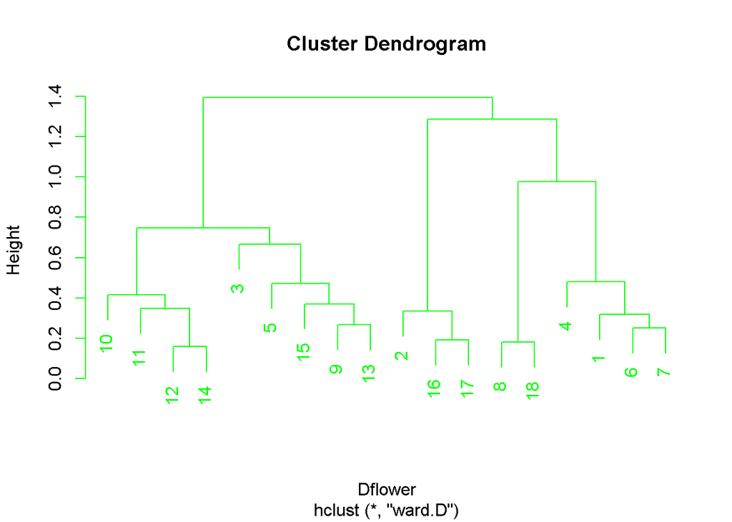

```r
plot(acflower1,col="green")
```

```r
par(mfrow=c(1,1))
```